# Part I - (Project - Ford GoBike)

# 1. Introduction

My chosen DataSet is showing information that covers over 180K records of individual rides made in a bike-sharing system covering the greater San Francisco Bay area in Feb-2019.

This notebook is mainly aimed to answer some questions such as:

- When are most trips taken in terms of time of day, day of the week, or month of the year?
- How long does the average trip take?
- Does the above depend on if a user is a subscriber or customer?

to answer these questions we need some exploratory & explanatory data analysis techniques like visualization also some data wrangling skills. to solve the question we will use python as programming language and some libraries such as: Pandas, Matplotlib and Seaborn

```python
import pandas as pd
import numpy as np
import seaborn as sns
import matplotlib.pyplot as plt

%matplotlib inline
#setting figure size
from matplotlib.pylab import rcParams
rcParams['figure.figsize'] = 8,8
# set plot dimensions
plt.figure(figsize=[14, 6])
```

# 2. Data Wrangling

## 2.1 Gathering

```python
from google.colab import files

uploaded = files.upload()

for fn in uploaded.keys():
  print('User uploaded file "{name}" with length {length} bytes'.format(
      name=fn, length=len(uploaded[fn])))
```

```
Saving 201902-fordgobike-tripdata.csv to 201902-fordgobike-tripdata.csv
User uploaded file "201902-fordgobike-tripdata.csv" with length 39422395 bytes
```

```python
filepath = "201902-fordgobike-tripdata.csv"
df = pd.read_csv(filepath)
```

## 2.2 Assessing

```python
df.head()
```

|  | duration_sec | start_time | end_time | start_station_id | start_station_name | start_station_latitude | start_station_longitude | end_station_id | end_station_name | end_station_latitude | end_station_longitude | bike_id | user_type | member_birth_year | member_gender | bike_share_for_all_trip |
| --- | --- | --- | --- | --- | --- | --- | --- | --- | --- | --- | --- | --- | --- | --- | --- | --- |
| 0 | 52185 | 2019-02-28 17:32:10.1450 | 2019-03-01 08:01:55.9750 | 21.0 | Montgomery St BART Station (Market St at 2nd St) | 37.789625 | -122.400811 | 13.0 | Commercial St at Montgomery St | 37.794231 | -122.402923 | 4902 | Customer | 1984.0 | Male | No |
| 1 | 42521 | 2019-02-28 18:53:21.7890 | 2019-03-01 06:42:03.0560 | 23.0 | The Embarcadero at Steuart St | 37.791464 | -122.391034 | 81.0 | Berry St at 4th St | 37.775880 | -122.393170 | 2535 | Customer | NaN | NaN | No |
| 2 | 61854 | 2019-02-28 12:13:13.2180 | 2019-03-01 05:24:08.1460 | 86.0 | Market St at Dolores St | 37.769305 | -122.426826 | 3.0 | Powell St BART Station (Market St at 4th St) | 37.786375 | -122.404904 | 5905 | Customer | 1972.0 | Male | No |
| 3 | 36490 | 2019-02-28 17:54:26.0100 | 2019-03-01 04:02:36.8420 | 375.0 | Grove St at Masonic Ave | 37.774836 | -122.446546 | 70.0 | Central Ave at Fell St | 37.773311 | -122.444293 | 6638 | Subscriber | 1989.0 | Other | No |
| 4 | 1585 | 2019-02-28 23:54:18.5490 | 2019-03-01 00:20:44.0740 | 7.0 | Frank H Ogawa Plaza | 37.804562 | -122.271738 | 222.0 | 10th Ave at E 15th St | 37.792714 | -122.248780 | 4898 | Subscriber | 1974.0 | Male | Yes |

```python
df.info()
```

```
<class 'pandas.core.frame.DataFrame'>
RangeIndex: 183412 entries, 0 to 183411
Data columns (total 16 columns):
 #   Column                   Non-Null Count   Dtype
---  ------                   --------------   -----
 0   duration_sec             183412 non-null  int64
 1   start_time               183412 non-null  object
 2   end_time                 183412 non-null  object
 3   start_station_id         183215 non-null  float64
 4   start_station_name       183215 non-null  object
 5   start_station_latitude   183412 non-null  float64
 6   start_station_longitude  183412 non-null  float64
 7   end_station_id           183215 non-null  float64
 8   end_station_name         183215 non-null  object
 9   end_station_latitude     183412 non-null  float64
 10  end_station_longitude    183412 non-null  float64
 11  bike_id                  183412 non-null  int64
 12  user_type                183412 non-null  object
 13  member_birth_year        175147 non-null  float64
 14  member_gender            175147 non-null  object
 15  bike_share_for_all_trip  183412 non-null  object
dtypes: float64(7), int64(2), object(7)
memory usage: 22.4+ MB
```

*Some Null values can be viewed in birth_year, gender columns, stations (start, end).*

```python
df.describe()
```

|  | duration_sec | start_station_id | start_station_latitude | start_station_longitude | end_station_id | end_station_latitude | end_station_longitude | bike_id | member_birth_year |
| --- | --- | --- | --- | --- | --- | --- | --- | --- | --- |
| count | 183412.000000 | 183215.000000 | 183412.000000 | 183412.000000 | 183215.000000 | 183412.000000 | 183412.000000 | 183412.000000 | 175147.000000 |
| mean | 726.078435 | 138.590427 | 37.771223 | -122.352664 | 136.249123 | 37.771427 | -122.352250 | 4472.906375 | 1984.806437 |
| std | 1794.389780 | 111.778864 | 0.099581 | 0.117097 | 111.515131 | 0.099490 | 0.116673 | 1664.383394 | 10.116689 |
| min | 61.000000 | 3.000000 | 37.317298 | -122.453704 | 3.000000 | 37.317298 | -122.453704 | 11.000000 | 1878.000000 |
| 25% | 325.000000 | 47.000000 | 37.770083 | -122.412408 | 44.000000 | 37.770407 | -122.411726 | 3777.000000 | 1980.000000 |
| 50% | 514.000000 | 104.000000 | 37.780760 | -122.398285 | 100.000000 | 37.781010 | -122.398279 | 4958.000000 | 1987.000000 |
| 75% | 796.000000 | 239.000000 | 37.797280 | -122.286533 | 235.000000 | 37.797320 | -122.288045 | 5502.000000 | 1992.000000 |
| max | 85444.000000 | 398.000000 | 37.880222 | -121.874119 | 398.000000 | 37.880222 | -121.874119 | 6645.000000 | 2001.000000 |

*Some member_birth_year values don't seem logical e.g min_value = 1878*

```python
# Check null value for each column
df.isna().sum()
```

```
duration_sec                  0
start_time                    0
end_time                      0
start_station_id            197
start_station_name          197
start_station_latitude        0
start_station_longitude       0
end_station_id              197
end_station_name            197
end_station_latitude          0
end_station_longitude         0
bike_id                       0
user_type                     0
member_birth_year          8265
member_gender              8265
bike_share_for_all_trip       0
dtype: int64
```

```python
# Check duplicated row
df.duplicated().sum()
```

```
0
```

```python
df.groupby(['member_birth_year'])['member_birth_year'].count().sort_values(ascending=True).head(40)
```

```
member_birth_year
1878.0       1
1928.0       1
1927.0       1
1910.0       1
1930.0       1
1944.0       2
1934.0       2
1920.0       3
1938.0       3
1901.0       6
1941.0       9
1939.0      11
1902.0      11
1946.0      19
1933.0      20
1942.0      21
1943.0      30
2001.0      34
1948.0      51
1900.0      53
1931.0      89
1949.0      99
1945.0     105
1955.0     134
1947.0     135
1953.0     158
1950.0     178
1951.0     180
1952.0     189
1954.0     301
1956.0     392
1958.0     517
1959.0     624
1957.0     807
1960.0     807
1961.0     821
1962.0     956
1966.0     989
1963.0    1151
1964.0    1189
Name: member_birth_year, dtype: int64
```

```python
df[df['member_birth_year']<1929]
```

|  | duration_sec | start_time | end_time | start_station_id | start_station_name | start_station_latitude | start_station_longitude | end_station_id | end_station_name | end_station_latitude | end_station_longitude | bike_id | user_type | member_birth_year | member_gender | bike_share_for_all_trip |
| --- | --- | --- | --- | --- | --- | --- | --- | --- | --- | --- | --- | --- | --- | --- | --- | --- |
| 1285 | 148 | 2019-02-28 19:29:17.6270 | 2019-02-28 19:31:45.9670 | 158.0 | Shattuck Ave at Telegraph Ave | 37.833279 | -122.263490 | 173.0 | Shattuck Ave at 55th St | 37.840364 | -122.264488 | 5391 | Subscriber | 1900.0 | Male | Yes |
| 10827 | 1315 | 2019-02-27 19:21:34.4360 | 2019-02-27 19:43:30.0080 | 343.0 | Bryant St at 2nd St | 37.783172 | -122.393572 | 375.0 | Grove St at Masonic Ave | 37.774836 | -122.446546 | 6249 | Subscriber | 1900.0 | Male | No |
| 16087 | 1131 | 2019-02-27 08:37:36.8640 | 2019-02-27 08:56:28.0220 | 375.0 | Grove St at Masonic Ave | 37.774836 | -122.446546 | 36.0 | Folsom St at 3rd St | 37.783830 | -122.398870 | 4968 | Subscriber | 1900.0 | Male | No |
| 17981 | 366 | 2019-02-26 19:53:38.5280 | 2019-02-26 19:59:44.9680 | 50.0 | 2nd St at Townsend St | 37.780526 | -122.390288 | 21.0 | Montgomery St BART Station (Market St at 2nd St) | 37.789625 | -122.400811 | 5226 | Subscriber | 1920.0 | Male | No |
| 18885 | 432 | 2019-02-26 17:48:59.0160 | 2019-02-26 17:56:11.3700 | 21.0 | Montgomery St BART Station (Market St at 2nd St) | 37.789625 | -122.400811 | 50.0 | 2nd St at Townsend St | 37.780526 | -122.390288 | 5319 | Subscriber | 1920.0 | Male | No |
| ... | ... | ... | ... | ... | ... | ... | ... | ... | ... | ... | ... | ... | ... | ... | ... | ... |
| 173711 | 993 | 2019-02-03 09:45:30.4640 | 2019-02-03 10:02:04.1690 | 375.0 | Grove St at Masonic Ave | 37.774836 | -122.446546 | 36.0 | Folsom St at 3rd St | 37.783830 | -122.398870 | 5445 | Subscriber | 1900.0 | Male | No |
| 177708 | 1527 | 2019-02-01 19:09:28.3870 | 2019-02-01 19:34:55.9630 | 343.0 | Bryant St at 2nd St | 37.783172 | -122.393572 | 375.0 | Grove St at Masonic Ave | 37.774836 | -122.446546 | 5286 | Subscriber | 1900.0 | Male | No |
| 177885 | 517 | 2019-02-01 18:38:40.4710 | 2019-02-01 18:47:18.3920 | 25.0 | Howard St at 2nd St | 37.787522 | -122.397405 | 30.0 | San Francisco Caltrain (Townsend St at 4th St) | 37.776598 | -122.395282 | 2175 | Subscriber | 1902.0 | Female | No |
| 182830 | 428 | 2019-02-01 07:45:05.9340 | 2019-02-01 07:52:14.9220 | 284.0 | Yerba Buena Center for the Arts (Howard St at ... | 37.784872 | -122.400876 | 67.0 | San Francisco Caltrain Station 2 (Townsend St... | 37.776639 | -122.395526 | 5031 | Subscriber | 1901.0 | Male | No |
| 183388 | 490 | 2019-02-01 00:39:53.1120 | 2019-02-01 00:48:03.3380 | 61.0 | Howard St at 8th St | 37.776513 | -122.411306 | 81.0 | Berry St at 4th St | 37.775880 | -122.393170 | 5411 | Subscriber | 1927.0 | Male | No |

77 rows × 16 columns

```python
# check for proportion of people born before 1920
born_before_1929 = len(df[df['member_birth_year']<1929])
before_1929_percent = born_before_1929/len(df)
print (f'People who were born before 1929 represent {(before_1929_percent*100):.2f} %')
```

```
People who were born before 1929 represent 0.04 %
```

unlogical year of birth values 1901, 1902 or 1878 ...

```python
# check for proportion of people born before 1920
other_gender = len(df[df['member_gender']=='Other'])
other_gender_percent = other_gender/len(df)
print (f'People who were registred Other represent {(other_gender_percent*100):.2f} %')
```

```
People who were registred Other represent 1.99 %
```

## 2.3 Cleaning

In this section we will try to clean our data to make easier in visualization and exploration first step is making a copy of our data then the cleaning technique Define, code, test

```python
df_clean = df.copy()
```

Problem:

```python
# Define: Change columns dtype based on it's value

# Code
dtype= {'start_time': 'datetime64',
        'end_time': 'datetime64',

        'start_station_id': 'object',
        'end_station_id': 'object',

        'start_station_latitude': 'object',
        'start_station_longitude':  'object',
        'end_station_latitude':  'object',
        'end_station_longitude':  'object',

        'bike_id': 'object',
        'user_type': 'category'}

df_clean = df_clean.astype(dtype)

# Test
df_clean.info()
```

```
<class 'pandas.core.frame.DataFrame'>
RangeIndex: 183412 entries, 0 to 183411
Data columns (total 16 columns):
 #   Column                   Non-Null Count   Dtype
---  ------                   --------------   -----
 0   duration_sec             183412 non-null  int64
 1   start_time               183412 non-null  datetime64[ns]
 2   end_time                 183412 non-null  datetime64[ns]
 3   start_station_id         183215 non-null  object
 4   start_station_name       183215 non-null  object
 5   start_station_latitude   183412 non-null  object
 6   start_station_longitude  183412 non-null  object
 7   end_station_id           183215 non-null  object
 8   end_station_name         183215 non-null  object
 9   end_station_latitude     183412 non-null  object
 10  end_station_longitude    183412 non-null  object
 11  bike_id                  183412 non-null  object
 12  user_type                183412 non-null  category
 13  member_birth_year        175147 non-null  float64
 14  member_gender            175147 non-null  object
 15  bike_share_for_all_trip  183412 non-null  object
dtypes: category(1), datetime64[ns](2), float64(1), int64(1), object(11)
memory usage: 21.2+ MB
```

Problem:

- Dropping NaN Values

```python
# Define : *Some Null values can be viewed in birth_year, gender columns, stations (start, end).*

# Code
df_clean = df_clean.dropna()
# Test
df_clean.info()
```

```
<class 'pandas.core.frame.DataFrame'>
Int64Index: 174952 entries, 0 to 183411
Data columns (total 16 columns):
 #   Column                   Non-Null Count   Dtype
---  ------                   --------------   -----
 0   duration_sec             174952 non-null  int64
 1   start_time               174952 non-null  datetime64[ns]
 2   end_time                 174952 non-null  datetime64[ns]
 3   start_station_id         174952 non-null  object
 4   start_station_name       174952 non-null  object
 5   start_station_latitude   174952 non-null  object
 6   start_station_longitude  174952 non-null  object
 7   end_station_id           174952 non-null  object
 8   end_station_name         174952 non-null  object
 9   end_station_latitude     174952 non-null  object
 10  end_station_longitude    174952 non-null  object
 11  bike_id                  174952 non-null  object
 12  user_type                174952 non-null  category
 13  member_birth_year        174952 non-null  float64
 14  member_gender            174952 non-null  object
 15  bike_share_for_all_trip  174952 non-null  object
dtypes: category(1), datetime64[ns](2), float64(1), int64(1), object(11)
memory usage: 21.5+ MB
```

Problem: Creating Age colmun from the year of birth column

```python
# Define: *for analysis purpose it would be better to have the age instead of the year of birth*
# code
df_clean['age'] = 2019 - df_clean['member_birth_year']
df_clean.drop('member_birth_year', axis=1, inplace=True)
# test
df_clean.info()
```

```
<class 'pandas.core.frame.DataFrame'>
Int64Index: 174952 entries, 0 to 183411
Data columns (total 16 columns):
 #   Column                   Non-Null Count   Dtype
---  ------                   --------------   -----
 0   duration_sec             174952 non-null  int64
 1   start_time               174952 non-null  datetime64[ns]
 2   end_time                 174952 non-null  datetime64[ns]
 3   start_station_id         174952 non-null  object
 4   start_station_name       174952 non-null  object
 5   start_station_latitude   174952 non-null  object
 6   start_station_longitude  174952 non-null  object
 7   end_station_id           174952 non-null  object
 8   end_station_name         174952 non-null  object
 9   end_station_latitude     174952 non-null  object
 10  end_station_longitude    174952 non-null  object
 11  bike_id                  174952 non-null  object
 12  user_type                174952 non-null  category
 13  member_gender            174952 non-null  object
 14  bike_share_for_all_trip  174952 non-null  object
 15  age                      174952 non-null  float64
dtypes: category(1), datetime64[ns](2), float64(1), int64(1), object(11)
memory usage: 21.5+ MB
```

Problem: delete all ages Above 90 take into consideration the date of the data (2019)

```python
# Define: delete all ages Above 90 take into consideration the date of the data (2019)

# Code
# Remove outliers in Birth year column
ids = df_clean[df_clean['age']>90].index
df_clean = df_clean.drop(index=ids)
# Test
df_clean.age.describe()
```

```
count    174875.000000
mean         34.160274
std           9.968641
min          18.000000
25%          27.000000
50%          32.000000
75%          39.000000
max          89.000000
Name: age, dtype: float64
```

Problem: Making start and end time more specific

```python
# Define Add day, week_day, hour, day_part columns from the start_time and end_time columns
# Code
time_intervals = [0,4,12,17,22,23]
time_labels=['Night/Early Morning', 'Morning', 'Afternoon', 'Evening', 'Night']
# Creating Features from time
df_clean['start_day'] = df_clean['start_time'].dt.day
df_clean['start_day_of_week'] = df_clean['start_time'].dt.day_name()
df_clean['start_hour'] = df_clean['start_time'].dt.hour
df_clean['end_day'] = df_clean['end_time'].dt.day
df_clean['end_day_of_week'] = df_clean['end_time'].dt.day_name()
df_clean['end_hour'] = df_clean['end_time'].dt.hour
df_clean['month'] = df_clean['start_time'].dt.month_name()

df_clean.drop('end_time', axis=1, inplace=True)
df_clean.drop('start_time', axis=1, inplace=True)

# Test
df_clean.head(3)
```

|  | duration_sec | start_station_id | start_station_name | start_station_latitude | start_station_longitude | end_station_id | end_station_name | end_station_latitude | end_station_longitude | bike_id | ... | member_gender | bike_share_for_all_trip | age | start_day | start_day_of_week | start_hour | end_day | end_day_of_week | end_hour | month |
| --- | --- | --- | --- | --- | --- | --- | --- | --- | --- | --- | --- | --- | --- | --- | --- | --- | --- | --- | --- | --- | --- |
| 0 | 52185 | 21.0 | Montgomery St BART Station (Market St at 2nd St) | 37.789625 | -122.400811 | 13.0 | Commercial St at Montgomery St | 37.794231 | -122.402923 | 4902 | ... | Male | No | 35.0 | 28 | Thursday | 17 | 1 | Friday | 8 | February |
| 2 | 61854 | 86.0 | Market St at Dolores St | 37.769305 | -122.426826 | 3.0 | Powell St BART Station (Market St at 4th St) | 37.786375 | -122.404904 | 5905 | ... | Male | No | 47.0 | 28 | Thursday | 12 | 1 | Friday | 5 | February |
| 3 | 36490 | 375.0 | Grove St at Masonic Ave | 37.774836 | -122.446546 | 70.0 | Central Ave at Fell St | 37.773311 | -122.444293 | 6638 | ... | Other | No | 30.0 | 28 | Thursday | 17 | 1 | Friday | 4 | February |

3 rows × 21 columns

```python
# Define creating categorical variable using pandas
# Code
for hour in ['start_hour', 'end_hour']:
  df_clean[f'{hour.split("_")[0]}_day_part']=pd.cut(df_clean[hour],
                                                    bins=time_intervals,
                                                    labels=time_labels,
                                                    include_lowest=True,
                                                    )
  # test
  display(df_clean[f'{hour.split("_")[0]}_day_part'].value_counts().sort_index().to_frame())
```

|  | start_day_part |
| --- | --- |
| Night/Early Morning | 2163 |
| Morning | 73443 |
| Afternoon | 58771 |
| Evening | 38926 |
| Night | 1572 |

|  | end_day_part |
| --- | --- |
| Night/Early Morning | 2303 |
| Morning | 71833 |
| Afternoon | 56896 |
| Evening | 42096 |
| Night | 1747 |

Problem: Drop Gender Outliers "Other" since it represents less than 2%

```python
# define removing outliers from DF
# Code
ids = df_clean[df_clean['member_gender']=='Other'].index
df_clean = df_clean.drop(index=ids)
# Test
df_clean.info()
```

```
<class 'pandas.core.frame.DataFrame'>
Int64Index: 171230 entries, 0 to 183411
Data columns (total 23 columns):
 #   Column                   Non-Null Count   Dtype
---  ------                   --------------   -----
 0   duration_sec             171230 non-null  int64
 1   start_station_id         171230 non-null  object
 2   start_station_name       171230 non-null  object
 3   start_station_latitude   171230 non-null  object
 4   start_station_longitude  171230 non-null  object
 5   end_station_id           171230 non-null  object
 6   end_station_name         171230 non-null  object
 7   end_station_latitude     171230 non-null  object
 8   end_station_longitude    171230 non-null  object
 9   bike_id                  171230 non-null  object
 10  user_type                171230 non-null  category
 11  member_gender            171230 non-null  object
 12  bike_share_for_all_trip  171230 non-null  object
 13  age                      171230 non-null  float64
 14  start_day                171230 non-null  int64
 15  start_day_of_week        171230 non-null  object
 16  start_hour               171230 non-null  int64
 17  end_day                  171230 non-null  int64
 18  end_day_of_week          171230 non-null  object
 19  end_hour                 171230 non-null  int64
 20  month                    171230 non-null  object
 21  start_day_part           171230 non-null  category
 22  end_day_part             171230 non-null  category
dtypes: category(3), float64(1), int64(5), object(14)
memory usage: 27.9+ MB
```

# 3 Exploration

- ### What is the structure of your dataset?

- #### What is/are the main feature(s) of interest in your dataset?

The main features of interest in this dataset is duration_sec, month, start and end different times and user_type column finally gender.

- #### What features in the dataset do you think will help support your investigation into your feature(s) of interest? Location, Age, Gender, User type, Bike Share status, Time

## 3.1 Univariate Exploration

I'll start by looking at the distribution of the main variable of interest: duration_sec

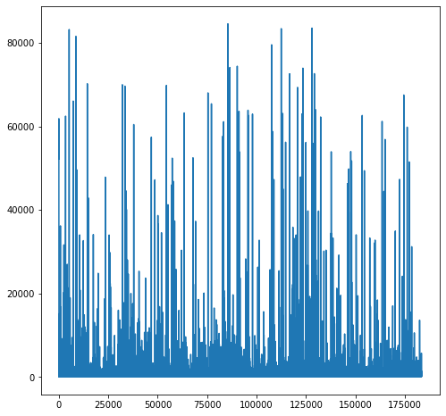

```python
df_clean['duration_sec'].plot()
```

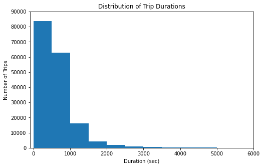

```python
binsize = 500
bins = np.arange(0, df_clean['duration_sec'].max()+binsize, binsize)

plt.figure(figsize=[8, 5])
plt.hist(data = df_clean, x = 'duration_sec', bins = bins)
plt.title('Distribution of Trip Durations')
plt.xlabel('Duration (sec)')
plt.ylabel('Number of Trips')
plt.axis([-100, 6000, 0, 90000])
plt.show()
```

Next up, the next variable of interest: user_type.

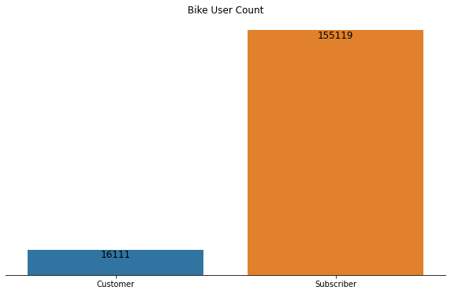

```python
plt.figure(figsize=(10,6))
base_color = sns.color_palette()[0]
ax = sns.countplot(data=df_clean, x ='user_type')

# add annotations
n_points = df_clean.shape[0]
cat_counts = df_clean['user_type'].value_counts()
locs, labels = plt.xticks() # get the current tick locations and labels

# loop through each pair of locations and labels
for loc, label in zip(locs, labels):

    # get the text property for the label to get the correct count
    count = cat_counts[label.get_text()]
    pct_string = '{}'.format(count)

    # print the annotation just below the top of the bar
    plt.text(loc, count-8, pct_string, va='top', ha='center', color = 'black', fontsize=12)

plt.title('Bike User Count')

# Remove unnecessary features
ax.spines['top'].set_visible(False)
ax.spines['right'].set_visible(False)
ax.spines['left'].set_visible(False)
plt.yticks([])
plt.ylabel('')
plt.xlabel('')

# Show the plot
plt.show();
```

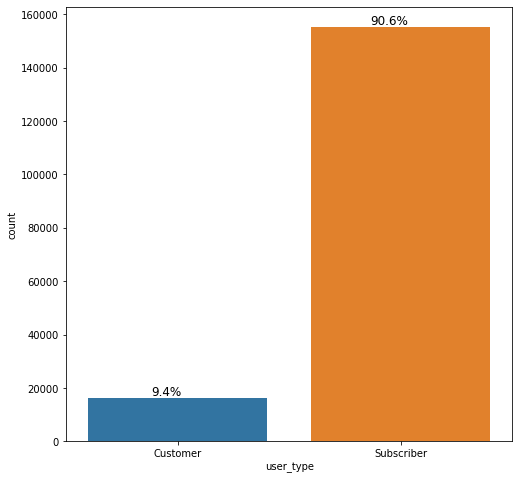

```python
ax = sns.countplot(x="user_type", data=df_clean)

# This function is used to change the count plot numbers into percentages
def without_hue(plot, feature):
    total = len(feature)
    for p in plot.patches:
        percentage = '{:.1f}%'.format(100 * p.get_height()/total)
        x = p.get_x() + p.get_width() / 2 - 0.05
        y = p.get_y() + p.get_height()
        plot.annotate(percentage, (x, y), size = 12, va='bottom', ha='center')

without_hue(ax, df_clean.user_type)
```

From the total entry of rows in 2019 data, less than 10% users are customers.

Now let's take a look at the age distribution

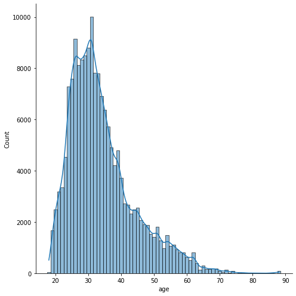

```python
sns.displot(df_clean, x="age", binwidth=3, bins=20, discrete=True, height=7, kde=True);
```

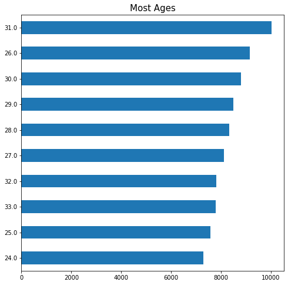

```python
plt.title('Most Ages', fontsize=15)
df_clean.age.value_counts(ascending=True).tail(10).plot.barh();
```

The next variable will be the time we will visualize start and end time variables

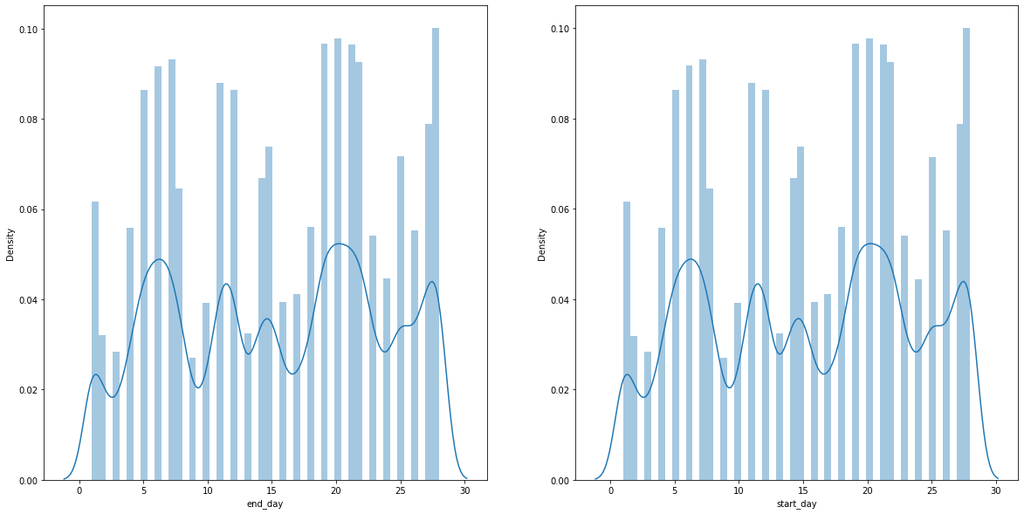

```python
# Start & End Day
nrows, ncols = 1, 2
cols = df.columns
color = sns.color_palette()[0]
fig, ax = plt.subplots(nrows=nrows, ncols=ncols, figsize=(20,10))
sns.distplot(data=df_clean['start_day'], color=color, ax = ax[1],kde=True);
sns.distplot(data=df_clean['end_day'],color=color, ax = ax[0],kde=True);
```

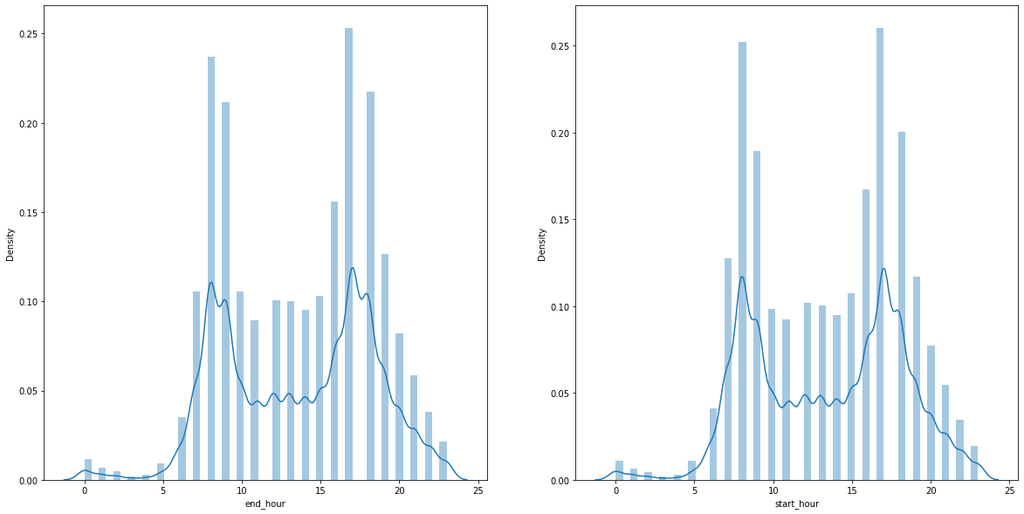

```python
# Start & End Hours
nrows, ncols = 1, 2
cols = df.columns
color = sns.color_palette()[0]
fig, ax = plt.subplots(nrows=nrows, ncols=ncols, figsize=(20,10))
sns.distplot(data=df_clean['start_hour'], color=color, ax = ax[1],kde=True);
sns.distplot(data=df_clean['end_hour'],color=color, ax = ax[0],kde=True);
```

```python
day_order = ['Monday', 'Tuesday', 'Wednesday', 'Thursday', 'Friday', 'Saturday', 'Sunday']
```

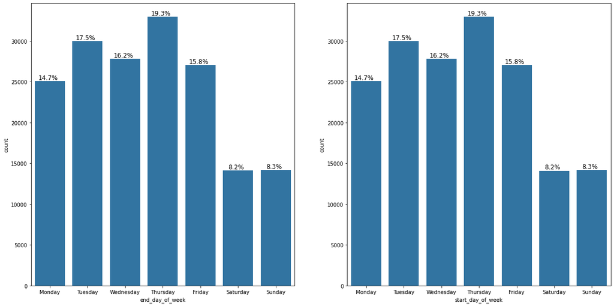

```python
# Start & End Day pf weeks
nrows, ncols = 1, 2
color = sns.color_palette()[0]
fig, ax = plt.subplots(nrows=nrows, ncols=ncols, figsize=(20,10))

plot1 = sns.countplot(data=df_clean['start_day_of_week'], order=day_order, color=color, ax = ax[1]);
without_hue(plot1, df_clean.start_day_of_week)
plot2 = sns.countplot(data=df_clean['end_day_of_week'], order=day_order, color=color, ax = ax[0]);
without_hue(plot2, df_clean.end_day_of_week)
```

```python
df_clean.month.value_counts()
```

```
February    171230
Name: month, dtype: int64
```

For the start and end day the plots looks almost identical, but for the start and end hour there is an obvious difference specially in the hour 9 and 22 and the rest similar. For the week day the most active day thursday and the least active are sunday and saturday

The last variable we can check for is the end and start station

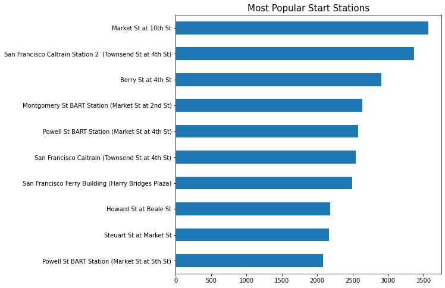

```python
plt.title('Most Popular Start Stations', fontsize=15)
df_clean.start_station_name.value_counts(ascending=True).tail(10).plot.barh();
```

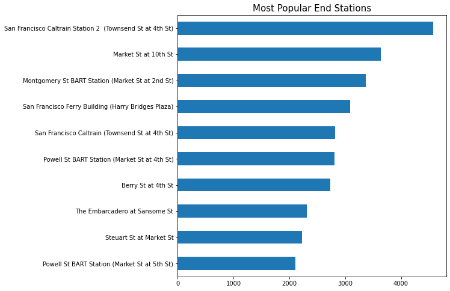

```python
plt.title('Most Popular End Stations', fontsize=15)
df_clean.end_station_name.value_counts(ascending=True).tail(10).plot.barh();
```

### Of the features you investigated, were there any unusual distributions? Did you perform any operations on the data to tidy, adjust, or change the form of the data? If so, why did you do this?

We did those operations to make our data tidy and get better analysis results.

## 3.2 Bivariate Exploration

The first values we gonna check are duration and age

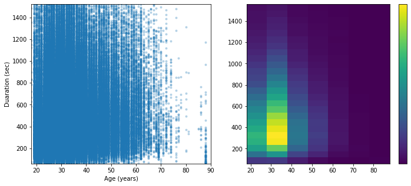

```python
plt.figure(figsize=[12,5])

plt.subplot(1, 2, 1)
plt.scatter(df_clean['age'], df_clean['duration_sec'], alpha = 0.25, marker = '.' )
plt.axis([18, 90, 60, df_clean['duration_sec'].quantile(0.95)])
plt.xlabel('Age (years)')
plt.ylabel('Duaration (sec)')

plt.subplot(1, 2, 2)
bins_y = np.arange(60, df_clean['duration_sec'].quantile(0.95)+60, 60)
bins_x = np.arange(18, 90+1, 10)
plt.hist2d(data=df_clean,x='age', y='duration_sec',
           bins = [bins_x, bins_y])
plt.colorbar(ticks=[10000, 20000, 30000, 40000]);
plt.show()
```

By looking at the plots it is clear that most frequent users of bikes are aged between 20 and 50. Higher duration is clocked by younger members.

Next, we are looking up user_type and duration then user_type with time

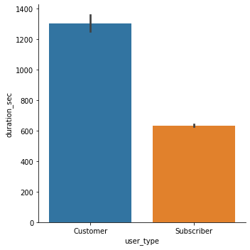

```python
sns.catplot(data=df_clean, x='user_type', ax = ax[0], y='duration_sec', kind='bar');
```

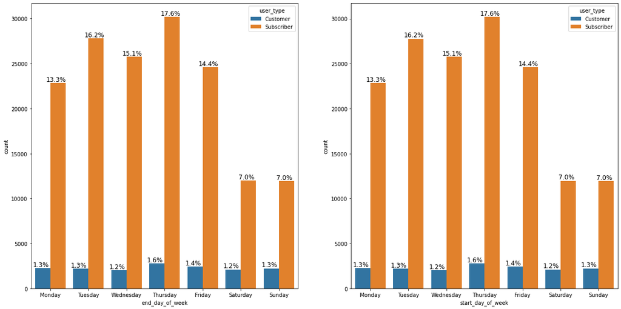

```python
# user type with the start an end day
nrows, ncols = 1, 2
fig, ax = plt.subplots(nrows=nrows, ncols=ncols, figsize=(20,10))

plot1 = sns.countplot(data=df_clean, x='start_day_of_week', order=day_order, ax = ax[1], hue='user_type');
without_hue(plot1, df_clean.start_day_of_week)

plot2 = sns.countplot(data=df_clean, x='end_day_of_week', order=day_order, ax = ax[0], hue='user_type');
without_hue(plot2, df_clean.end_day_of_week)
```

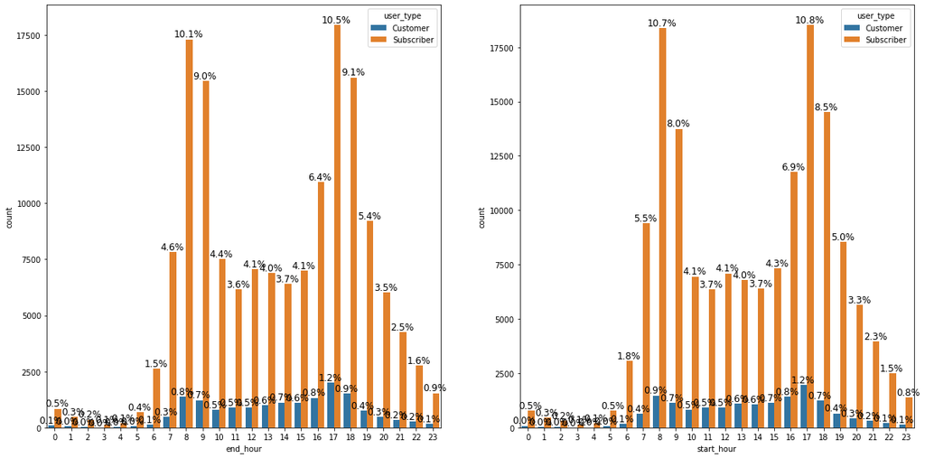

```python
# user type with the start an end hour
nrows, ncols = 1, 2
fig, ax = plt.subplots(nrows=nrows, ncols=ncols, figsize=(20,10))

plot1 = sns.countplot(data=df_clean, x='start_hour', ax = ax[1], hue='user_type');
without_hue(plot1, df_clean.start_hour)

plot2 = sns.countplot(data=df_clean, x='end_hour', ax = ax[0], hue='user_type');
without_hue(plot2, df_clean.end_hour)
```

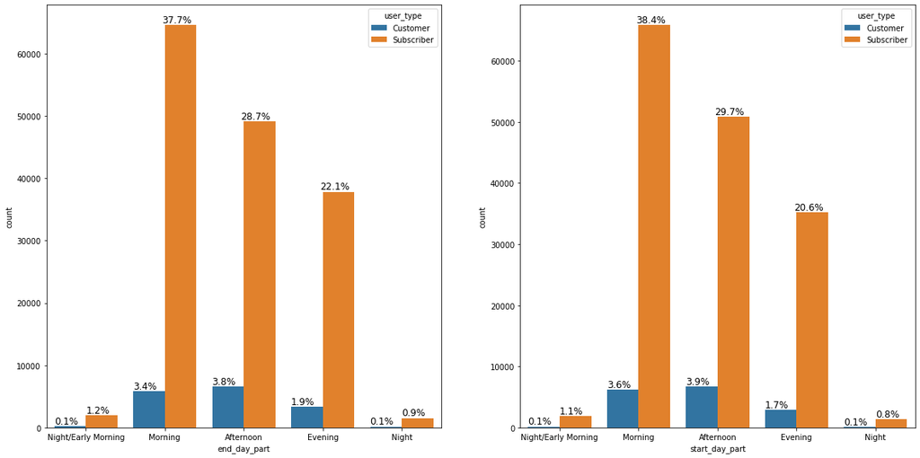

```python
# user type with the start and end day part
nrows, ncols = 1, 2
fig, ax = plt.subplots(nrows=nrows, ncols=ncols, figsize=(20,10))
plot1 = sns.countplot(data=df_clean, x='start_day_part', ax = ax[1], hue='user_type');
without_hue(plot1, df_clean.start_day_part)
plot2 = sns.countplot(data=df_clean, x='end_day_part', ax = ax[0], hue='user_type');
without_hue(plot2, df_clean.end_day_part)
```

it is so clear that customer count is less than subscriber but for the rid duration customers are way higher thant subscriber

Next checking time with duration

```python
# Start & End day with duration
data = df_clean[["start_day_of_week", "end_day_of_week", "duration_sec"]]
# melting start and end day of the week into categories
data = data.melt(id_vars=['duration_sec'], var_name='start/end', value_name='day')
data.head(3)
```

|  | duration_sec | start/end | day |
| --- | --- | --- | --- |
| 0 | 52185 | start_day_of_week | Thursday |
| 1 | 61854 | start_day_of_week | Thursday |
| 2 | 1585 | start_day_of_week | Thursday |

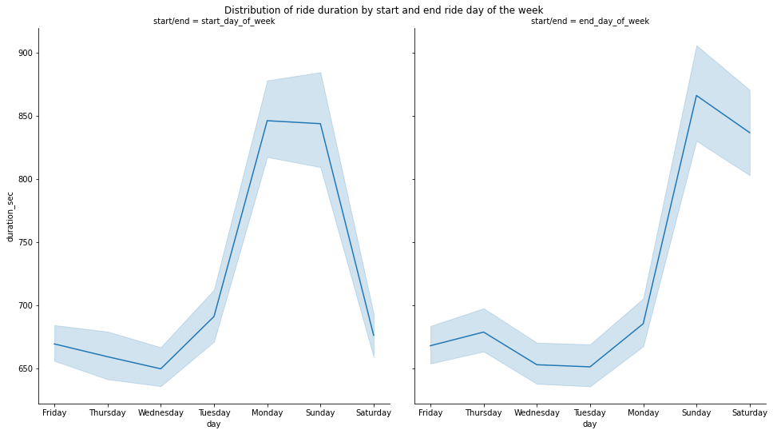

```python
# plotting
g=sns.relplot(
    data=data,
    x='day',
    y='duration_sec',
    col="start/end",
    kind="line");
# Adding Main title
plt.suptitle("Distribution of ride duration by start and end ride day of the week")
## Plot Dimensions
g.fig.set_size_inches(14,8);
```

```python
# Start & End hour with duration
data = df_clean[["start_hour", "end_hour", "duration_sec"]]
# melting start and end hour into categories
data = data.melt(id_vars=['duration_sec'], var_name='start/end', value_name='hour')
data.head(3)
```

|  | duration_sec | start/end | hour |
| --- | --- | --- | --- |
| 0 | 52185 | start_hour | 17 |
| 1 | 61854 | start_hour | 12 |
| 2 | 1585 | start_hour | 23 |

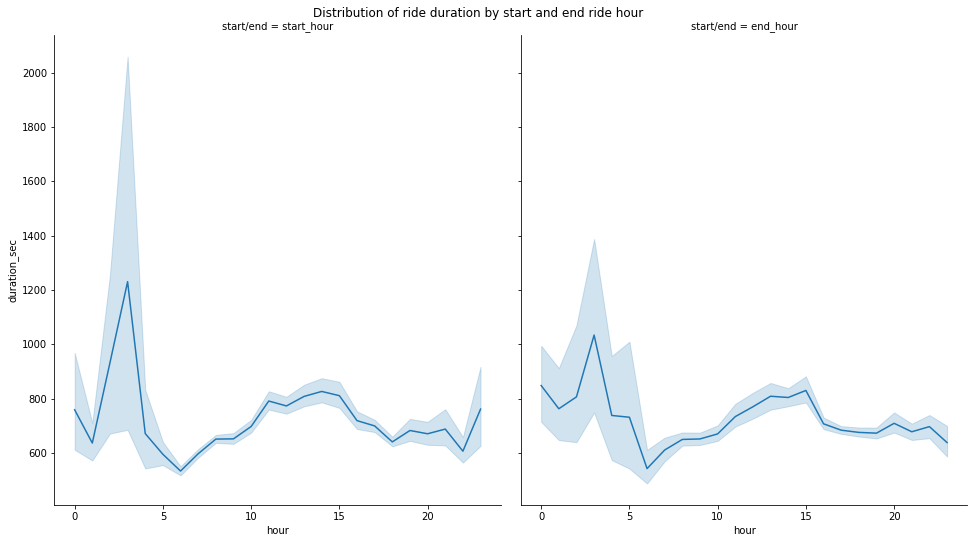

```python
# plotting
g=sns.relplot(
    data=data,
    x='hour',
    y='duration_sec',
    col="start/end",
    kind="line"
    );
# Adding Main title
plt.suptitle("Distribution of ride duration by start and end ride hour")
## Plot Dimensions
g.fig.set_size_inches(14,8);
```

The duration is very high in the weekend than it is in the other days Also people who ride before 5 with the most ride duration

our last variables are gender and duration

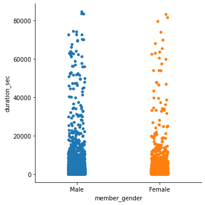

```python
sns.catplot(data=df_clean, x='member_gender', ax = ax[0], y='duration_sec');
```

## 3.3 Multivariate Exploration

Create plots of three or more variables to investigate your data even further.

### 3.3.1 Age and duration with Gender or user type

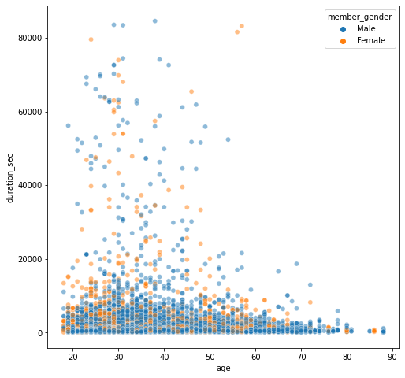

```python
# Age and duration with gender
sns.scatterplot(data=df_clean,y='duration_sec',x='age', alpha=0.5, hue='member_gender', legend='full')
```

Under the duration of 20000 and between age 20 and 60 it is clear that both male and are close. However Above 60000 second in the same range of age male have littile more values. But it is clear for both genders above the age of 60 no values above 20000

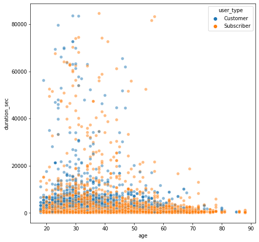

```python
# Age and duration with user type
sns.scatterplot(data=df_clean,y='duration_sec',x='age', alpha=0.5, hue='user_type', legend='full')
```

most of customer and subcribers rides are under 20000 in all ages. However above the age of 70 most riders are subscribers

### Time and duration with gender and user_type

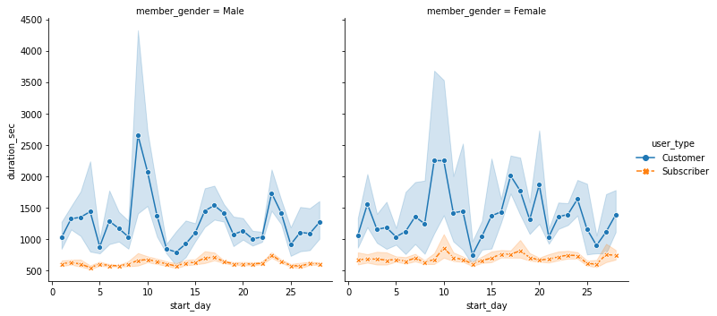

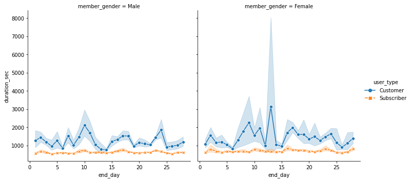

```python
# Start and End day
sns.relplot(
    data=df_clean, kind="line",
    x="start_day", y="duration_sec", col="member_gender",
    hue="user_type", style="user_type", ax = ax[1], markers=True,
)
sns.relplot(
    data=df_clean, kind="line",
    x="end_day", y="duration_sec", col="member_gender",
    hue="user_type", style="user_type", ax = ax[0], markers=True,
)
```

- For male customers most riding duration when the customer starts the ride in the second week of the month
- For male customers most rides duration ends with the 10th of the month
- For Female customers the rides with the most duration are in the second week of the month too
- For Female customers rides ends between the 10th and the 15th are with the most duration
- Subscribers both male and female don't give that much of details

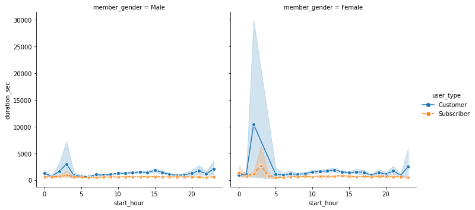

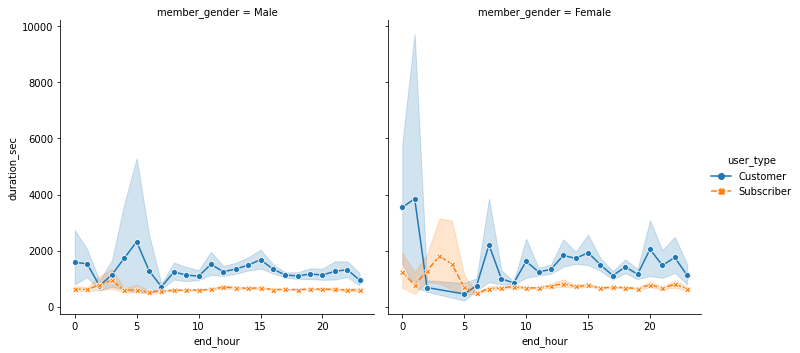

```python
# Start and End day
sns.relplot(
    data=df_clean, kind="line",
    x="start_hour", y="duration_sec", col="member_gender",
    hue="user_type", style="user_type", ax = ax[1], markers=True,
)
sns.relplot(
    data=df_clean, kind="line",
    x="end_hour", y="duration_sec", col="member_gender",
    hue="user_type", style="user_type", ax = ax[0], markers=True,
)
```

```python
# selecting columns to plot
cols=['start_day_of_week', 'end_day_of_week', 'duration_sec', 'member_gender']
# creating new data
plot_data = df_clean[cols]
# Melting data
plot_data = plot_data.melt(id_vars=['duration_sec', 'member_gender'], var_name='start/end', value_name='day')
plot_data.head(2)
```

|  | duration_sec | member_gender | start/end | day |
| --- | --- | --- | --- | --- |
| 0 | 52185 | Male | start_day_of_week | Thursday |
| 1 | 61854 | Male | start_day_of_week | Thursday |

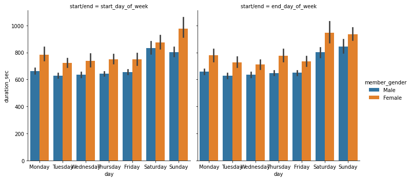

```python
## Plotting
sns.catplot(
    data=plot_data,
    x="day",
    y="duration_sec",
    hue="member_gender",
    col="start/end",
    order=day_order,
    kind="bar",
)
```

- Male and females most duration rides are in the Weekend
- in All week days female riding duration is bigger than male riding duration

```python
# selecting columns to plot
cols=['start_day_of_week', 'end_day_of_week', 'duration_sec', 'user_type']
# creating new data
plot_data = df_clean[cols]
# Melting data
plot_data = plot_data.melt(id_vars=['duration_sec', 'user_type'], var_name='start/end', value_name='day')
plot_data.head(2)
```

|  | duration_sec | user_type | start/end | day |
| --- | --- | --- | --- | --- |
| 0 | 52185 | Customer | start_day_of_week | Thursday |
| 1 | 61854 | Customer | start_day_of_week | Thursday |

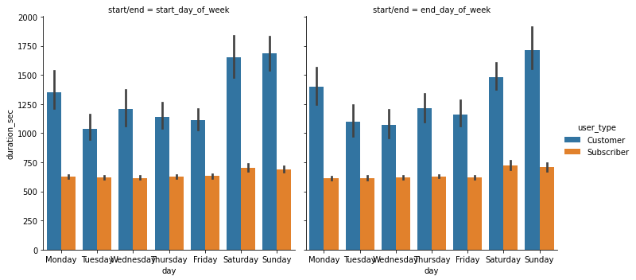

```python
## Plotting
sns.catplot(
    data=plot_data,
    x="day",
    y="duration_sec",
    hue="user_type",
    col="start/end",
    order=day_order,
    kind="bar",
)
```

- Subscribers riding is stable in all the week
- Customers riding duration peak is in the weekend
- Customers riding duration are higher than subscribers in the whole week

#### Talk about some of the relationships you observed in this part of the investigation. Were there features that strengthened each other in terms of looking at your feature(s) of interest?

Yes. The type of user and the gender has an influence on the use of this service.

#### Were there any interesting or surprising interactions between features?

- It was so surprising to find that the of riding duration is between 3 am and 5 am for male and female customers and subscribers

```python
# Export cleaned dataframe to CSV file for slide deck

# Code
df_clean.to_csv('201902-fordgobike-tripdata_clean.csv', index=None)
df_check = pd.read_csv('201902-fordgobike-tripdata_clean.csv')

# Test
df_check
```

[output not shown]